# OWA Lineage CTmax Project

2022-12-14

# Sample sizes

This summary reports the results of 4 replicate CTmax trials. The four lineages were sampled randomly for each replicate experiment, with one replicate culture per lineage per run.

```r
full_data %>%
  count(lineage) %>%
  knitr::kable()
```

| lineage | n |
| --- | --- |
| AA | 11 |
| AH | 8 |
| HA | 13 |
| HH | 8 |

# Trait measurements

## Body length

All copepods were measured after the CTmax assay. These length measurements are shown below.

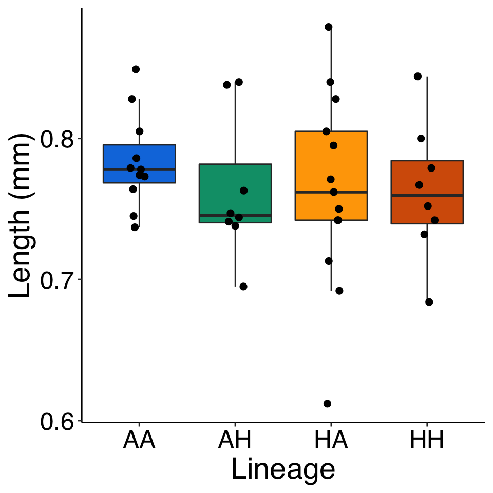

```r
ggplot(full_data, aes(x = lineage, y = length, fill = lineage)) +
  geom_boxplot(outlier.colour = NA) +
  geom_point(size = 2, position = position_jitter(width = 0.1, height = 0)) +
  scale_fill_manual(values = lineage_cols) +
  labs(x = "Lineage",
       y = "Length (mm)") +
  theme_matt(base_size = 18) +
  theme(legend.position = "none")
```

## CTmax

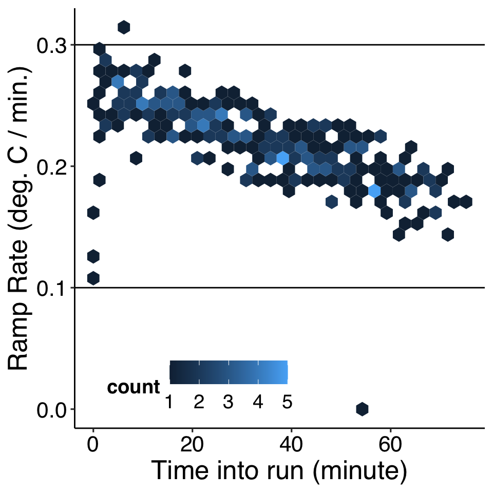

```r
ramp_record2 = ramp_record %>%
  group_by(run, minute_interval) %>%
  summarise(mean_ramp = mean(ramp_per_minute)) %>%
  drop_na(minute_interval, mean_ramp)

ggplot(ramp_record2, aes(x = minute_interval, y = mean_ramp)) +
  geom_hline(yintercept = 0.3) +
  geom_hline(yintercept = 0.1) +
  #geom_point() +
  geom_hex(bins = 30) +
  #scale_fill_continuous(lim=c(2,25), na.value=NA) +
  #ylim(0,0.32) +
  labs(y = "Ramp Rate (deg. C / min.)",
       x = "Time into run (minute)") +
  theme_matt(base_size = 16) +
  theme(legend.position = c(0.3, 0.1),
        legend.direction = "horizontal")
```

Individuals are monitored until they reach their thermal limit, indicated by a lack of responsiveness to stimuli. This is traditionally considered an “ecological death” endpoint. Measured CTmax values are shown below.

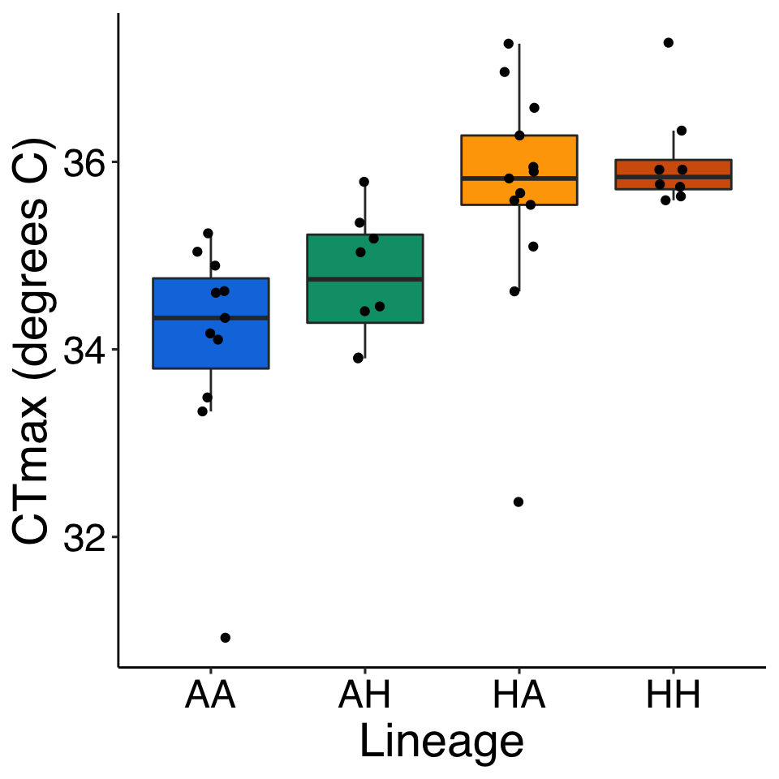

```r
ggplot(full_data, aes(x = lineage, y = ctmax, fill = lineage)) +
  geom_boxplot(outlier.colour = NA) +
  geom_point(position = position_jitter(width = 0.1, height = 0)) +
  scale_fill_manual(values = lineage_cols) +
  labs(x = "Lineage",
       y = "CTmax (degrees C)") +
  theme_matt(base_size = 18) +
  theme(legend.position = "none")
```

# Trait correlations

Across species, thermal limits tend to decrease with increasing body size. The relationship between measured lengths and CTmax from these assays is shown below.

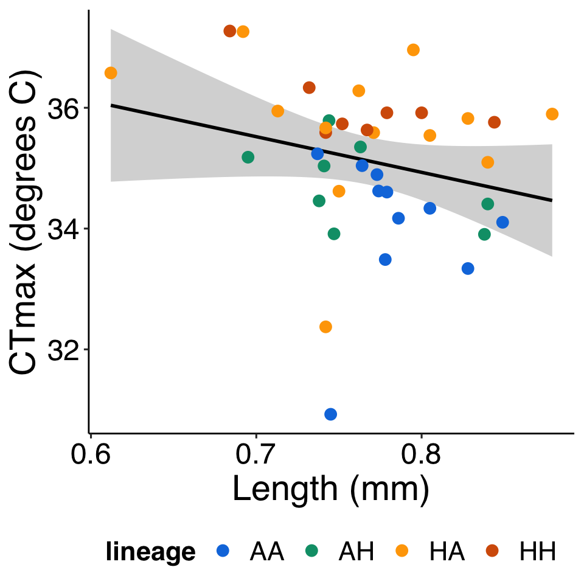

```r
ggplot(full_data, aes(x = length, y = ctmax)) +
  geom_smooth(method = "lm", colour = "black") +
  geom_point(size = 3, aes(colour = lineage)) +
  scale_colour_manual(values = lineage_cols) +
  labs(x = "Length (mm)",
       y = "CTmax (degrees C)") +
  theme_matt(base_size = 18) +
  theme(legend.position = "bottom")
```